# Indice de felicidad y canciones

Hugo Valenzuela

13/12/2021

## Contexto

En este proyecto se busca relacionar el índice de felicidad mundial con la las propiedades de audio de las canciones mas escuchadas en los distintos países. Para esto, se usará los datos oficiales del World Happiness Report para el índice de felicidad, y de Spotify para las canciones más escuchadas y sus características.

Se buscan investigar los siguientes puntos

- ¿Hay una correlación entre el índice de felicidad y la positividad/negatividad en las canciones más populares?
- ¿Se puede diferenciar un patrón en las canciones populares de un país en base a su índice de felicidad?

## Librerias necesarias

Librerias para correr este código

```r
library(readr)
library(stringr)
library(dplyr)
library(ggplot2)
library(DataExplorer)
```

## Lectura de datos

```r
fel_top50_read <-  read_csv("./data/felicidad-top50.csv",
                          show_col_types = FALSE)
```

### Valores perdidos

Al descargarse y limpiarse los datos, se comprobó que no hubiera datos perdidos, se vuelve a hacer

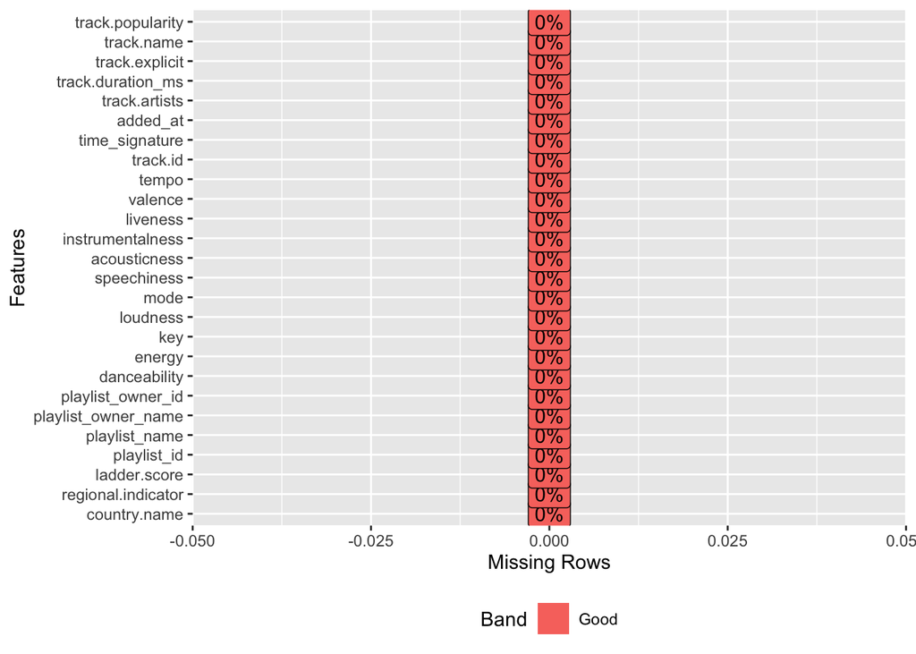

```r
plot_missing(fel_top50_read)
```

### Eligiendo las columnas

En este caso no interesa el nombre de las canciones ni los artistas, así que se procede a elegir las columnas en su mayoría numéricas del dataframe leido

```r
columnas_subset <- c("country.name", "ladder.score",
               "danceability", "energy", "loudness",
               "speechiness", "acousticness", "instrumentalness",
               "liveness", "valence", "track.duration_ms",
               "track.explicit")
fel_top50_subset <- fel_top50_read[ , columnas_subset]
```

### Reformateo de columnas

Cambiamos la característica de duración en milisegundos a minutos

```r
fel_top50_df <- fel_top50_subset %>%
  mutate(track.duration_ms = track.duration_ms / (1000.0 * 60.)) %>%
  plyr::rename(c("track.duration_ms" = "track.duration_min"))
```

### Diccionario de datos

Un diccionario describiendo las variables puede encontrarse en el archivo `diccionario.xlsx` en la carpeta `data`.

## Análisis Exploratorio de Datos

### Correlaciones

Veamos si hay variables muy correlacionadas entre sí

```
## 1 features with more than 20 categories ignored!
## country.name: 65 categories
```

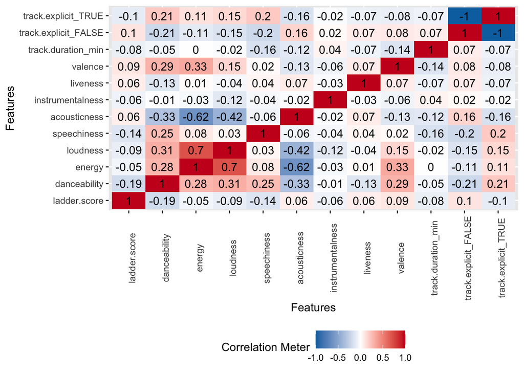

```r
plot_correlation(fel_top50_df)
```

Se ve que la variable **energy** y **loudness** están muy correlacionadas de manera positiva, de $0.7$, por lo tanto se eliminará la columna loudness. Esto porque están siendo redundantes las dos, ya que el algoritmo de Spotify calcula la variable **energy** a partir de la sonoridad **loudness**.

```r
fel_top50_df <- fel_top50_df %>% select(-loudness)
```

Se ve además que ninguna variable está con correlación alta con el índice de felicidad (ladder.score).

### Distribucion de las características

Primero unos histogramas para tener la idea de la distribución de los datos

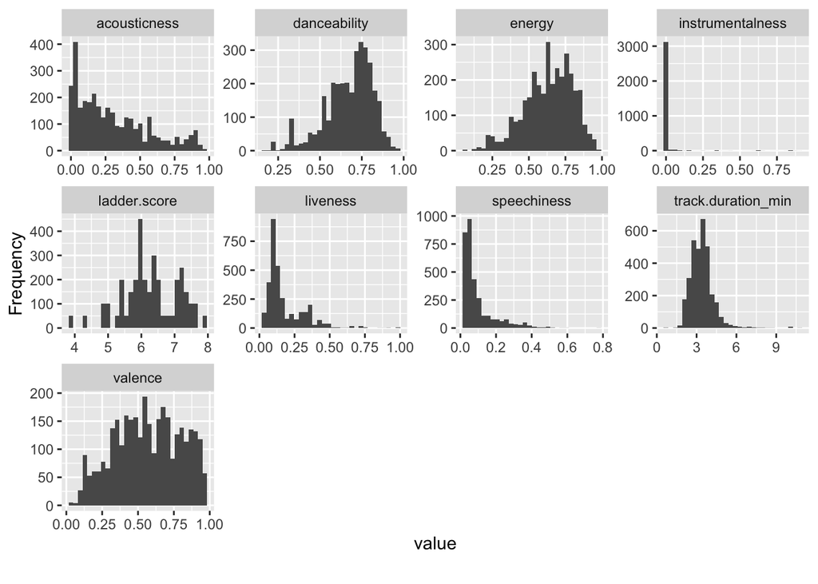

```r
plot_histogram(fel_top50_df)
```

**resumen**

```r
summary(fel_top50_df)
```

```
##  country.name        ladder.score    danceability        energy
##  Length:3250        Min.   :3.819   Min.   :0.1750   Min.   :0.0594
##  Class :character   1st Qu.:5.840   1st Qu.:0.5910   1st Qu.:0.5260
##  Mode  :character   Median :6.180   Median :0.7060   Median :0.6460
##                     Mean   :6.258   Mean   :0.6737   Mean   :0.6355
##                     3rd Qu.:7.064   3rd Qu.:0.7710   3rd Qu.:0.7660
##                     Max.   :7.842   Max.   :0.9750   Max.   :0.9750
##   speechiness       acousticness       instrumentalness       liveness
##  Min.   :0.02300   Min.   :0.0000384   Min.   :0.0000000   Min.   :0.0256
##  1st Qu.:0.03840   1st Qu.:0.0830250   1st Qu.:0.0000000   1st Qu.:0.0921
##  Median :0.05510   Median :0.2370000   Median :0.0000000   Median :0.1205
##  Mean   :0.09478   Mean   :0.3000714   Mean   :0.0083250   Mean   :0.1783
##  3rd Qu.:0.10400   3rd Qu.:0.4577500   3rd Qu.:0.0000376   3rd Qu.:0.2400
##  Max.   :0.77400   Max.   :0.9680000   Max.   :0.9050000   Max.   :0.9770
##     valence       track.duration_min track.explicit
##  Min.   :0.0386   Min.   : 0.635     Mode :logical
##  1st Qu.:0.3970   1st Qu.: 2.810     FALSE:2226
##  Median :0.5640   Median : 3.353     TRUE :1024
##  Mean   :0.5669   Mean   : 3.386
##  3rd Qu.:0.7610   3rd Qu.: 3.796
##  Max.   :0.9720   Max.   :10.720
```

La variable **instrumentalness** parece estar muy concentrada cerca del 0 lo que indica que la gran mayoría de las canciones son con contenido de canto, veamos su boxplot

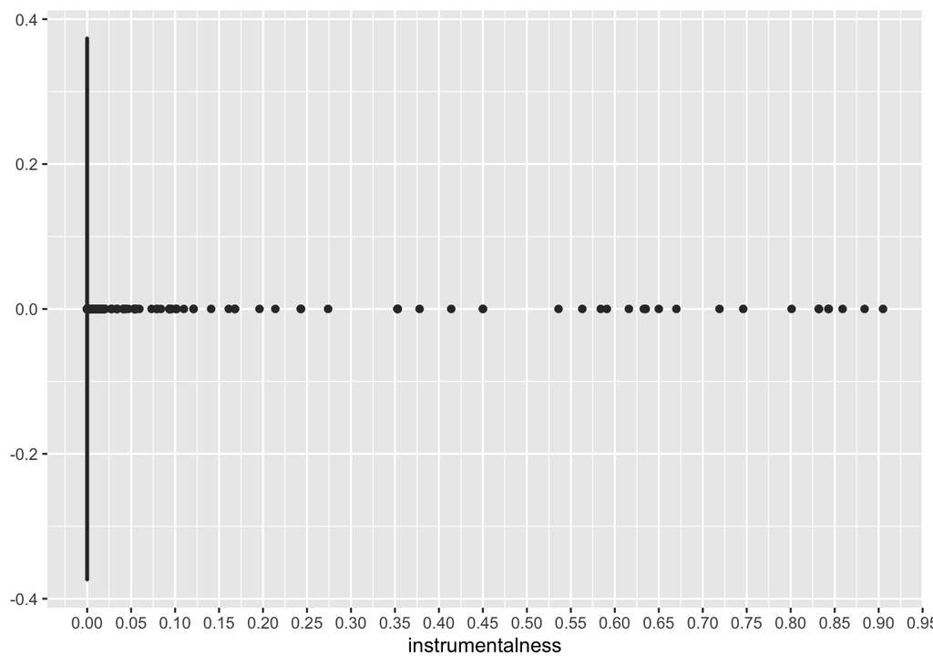

```r
fel_top50_df %>% ggplot(aes(x = instrumentalness)) +
  geom_boxplot() +
  scale_x_continuous(breaks = scales::pretty_breaks(n = 20))
```

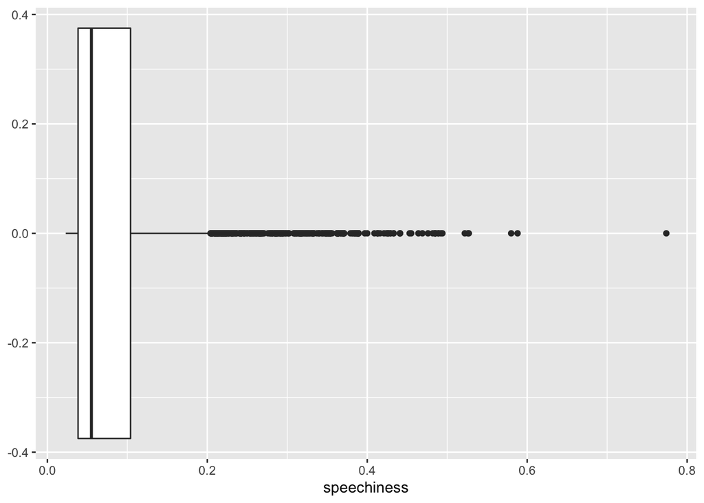

```r
fel_top50_df %>% ggplot(aes(x = speechiness)) +
  geom_boxplot()
```

Y se ve también que **speechiness** tiene valores muy bajos y outliers después de $0.2$. Los valores muy bajos de speechiness e instrumentalness lo que nos indica es que la mayoría de las canciones son cantadas y no instrumentales, pues de acuerdo al diccionario de datos los valores bajos de speechiness corresponden a canciones sin palabras habladas (más canto y música) mientras que valores bajos de instrumentalness indica que las canciones tienen contenido cantado.

### Redución de variables y PCA

De acuerdo a lo anterior, se remueven las columnas **instrumentalness** y **speechiness** pues no servirán tanto para discriminar la instrumentalicazión o la cantidad de lo cantado en una canción.

```r
fel_top50_df <- fel_top50_df %>%
  select(-c("instrumentalness", "speechiness"))
```

Ahora se aplicará un algoritmo de Análisis de Componentes Principales (PCA) para ver qué características contribuyen más a la variabilidad de los datos.

Pero antes, crear un subconjunto de los datos con solamente las características numéricas

```r
fel_top50_num <- fel_top50_df %>%
  select(c("danceability", "energy", "acousticness", "liveness", "valence",
           "track.duration_min")
         )
```

**PAC**

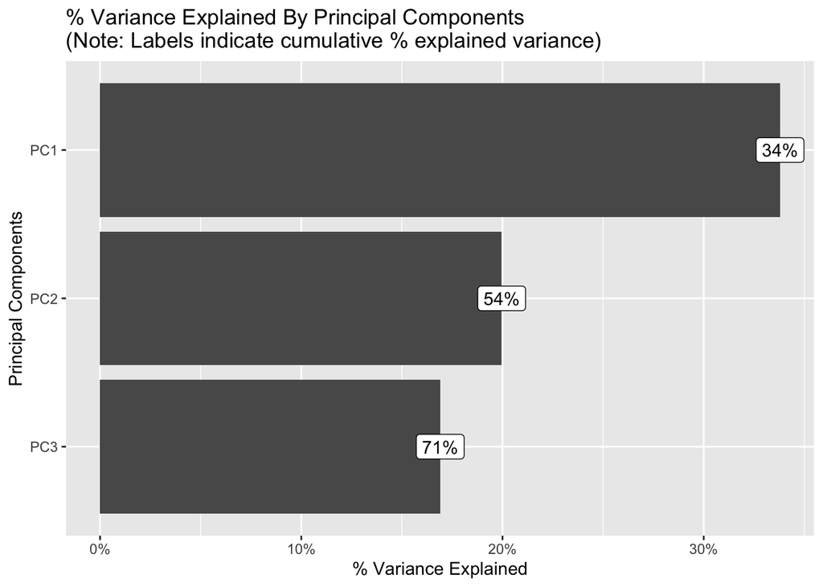

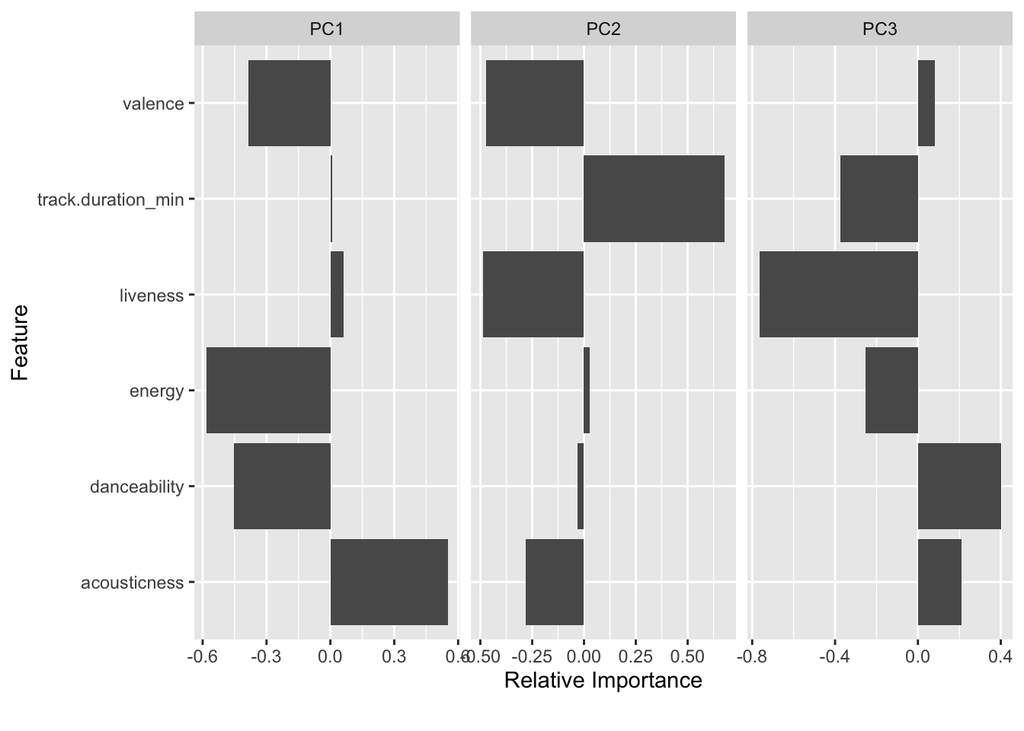

```r
plot_prcomp(fel_top50_num)
```

Podemos ver que las $6$ características *danceability*, *energy*, *acousticness*”, “*liveness*, *valence* y *track.duration_min* explican el $71\%$ de la variabilidad de los datos en 3 componentes principales, las cuales podrían usarse en un algoritmo de aprendizaje automático supervisado.

### Categorización de la variable independiente

Ahora, para trabajar con el índice de felicidad se hacen categorías, en lugar de trabajarlo como un continuo. Esto para facilitar el análisis exploratorio con las visualizaciones. Veamos su boxplot y densidad aproximada

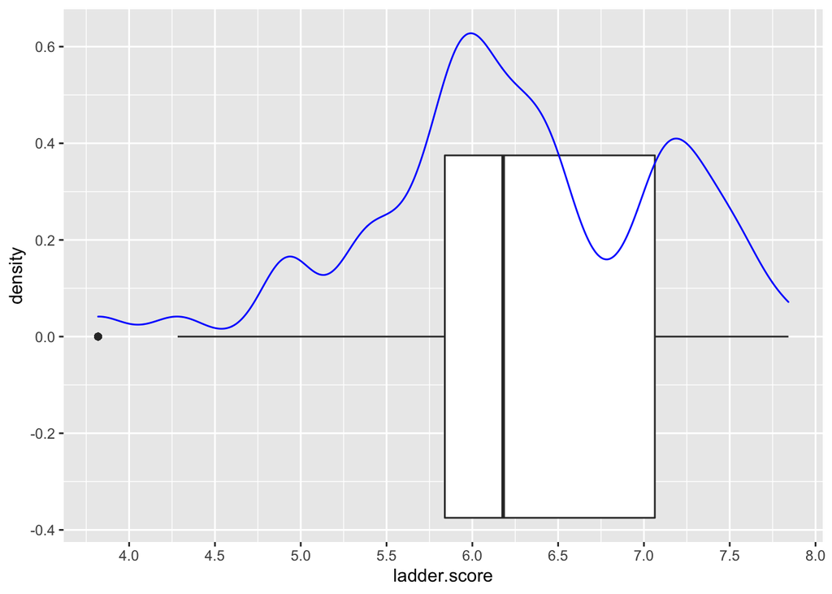

```r
fel_top50_df %>% ggplot(aes(x = ladder.score)) +
  geom_boxplot() + geom_density(color="blue") +
  scale_x_continuous(breaks = scales::pretty_breaks(n = 10))
```

Se deciden hacer las categorías de acuerdo al boxplot, de la siguiente manera

- **Bajo:** [mínimo, primer cuartil) 25%
- **Medio:** [primer cuartil, tercer cuartil) 50%
- **Alto:** [tercer cuartil, máximo] 25%

así, para las categorías bajo, medio y alto quedarán el 25%, 50% y 25% de los datos, respectivamente.

```r
fel_top50_cat <- fel_top50_df %>%
  mutate(fel.categoria = cut(ladder.score,
                             breaks = c(0,
                                        quantile(ladder.score)[[2]],
                                        quantile(ladder.score)[[4]],
                                        Inf),
                            labels = c("bajo", "medio", "alto"))
         )

# las proporciones de las categorias

fel_top50_cat %>% group_by(fel.categoria) %>%
  summarise(proporcion = n()/nrow(fel_top50_cat))
```

```
## # A tibble: 3 × 2
##   fel.categoria proporcion
##   <fct>              <dbl>
## 1 bajo               0.262
## 2 medio              0.492
## 3 alto               0.246
```

El dataframe `fel_top50_cat` servirá para trabajar en las siguientes visualizaciones.

## Visualizaciones

Hacemos unos **boxplots** de acuerdo a las categorías, para ver si a simple viste puede observarse algun patrón o separación en las características.

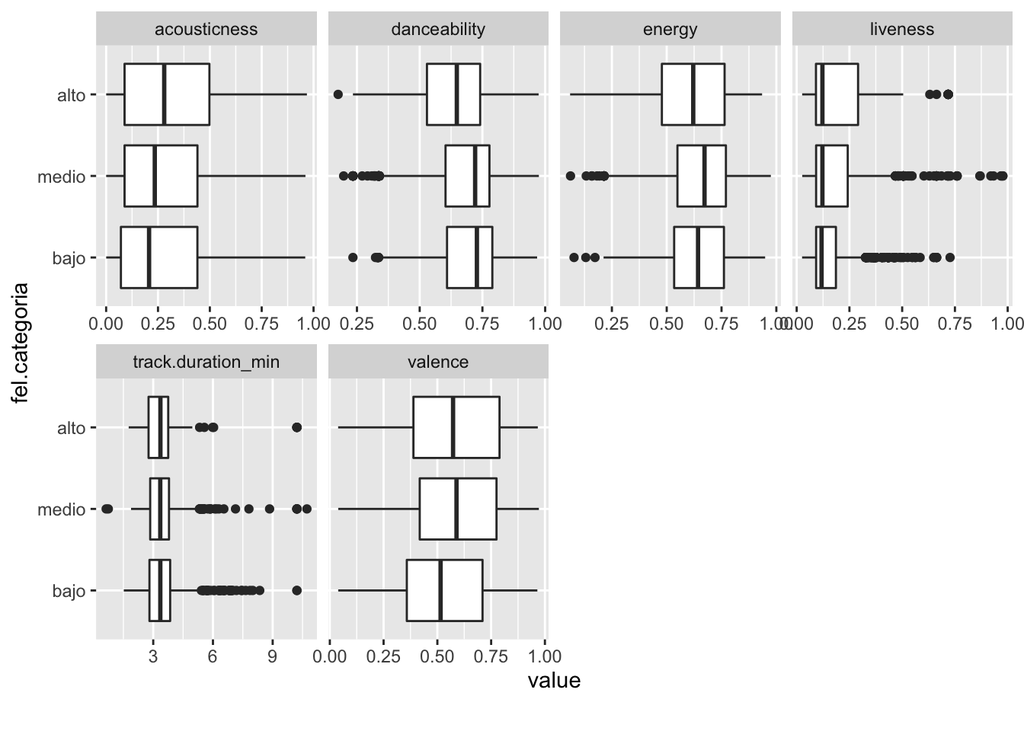

```r
fel_top50_cat %>% select(-c("country.name", "ladder.score")) %>%
  plot_boxplot(by = "fel.categoria")
```

Puede observarse que los datos están dispersos de manera muy similar al separarlos en las $3$ categorías dele índice de felicidad.

Ahora, un **diagrama de dispersión** de la característica *valence* que indica la positividad, en contra del índice de felicidad *ladder.score*.

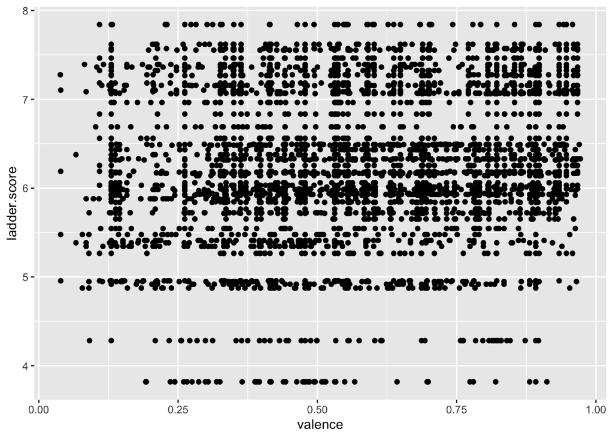

```r
fel_top50_cat %>% select(c("ladder.score", "valence")) %>%
  ggplot(aes(x = valence, y = ladder.score)) +
  geom_point()
```

No es muy claro visualizarlo de esta manera, por lo que se toman los promedios de valence y el índice de felicidad para cada país (éste último sin promedio, es uno solo por país), teniendo

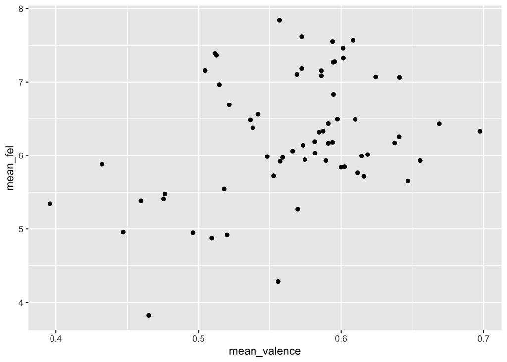

```r
valence_fel <- fel_top50_cat %>% select(c("ladder.score", "valence", "country.name")) %>%
  group_by(country.name) %>%
  summarise(mean_fel = mean(ladder.score),
            mean_valence = mean(valence))
valence_fel %>% ggplot(aes(x = mean_valence, y = mean_fel)) +
  geom_point()
```

Ya se observa más separado, con una correlación de 0.3597504.

Sin embargo, claramente no es una relación lineal, por lo que sería más adecuado aplicar algún algoritmo de aprendizaje automático no supervisado, como clustering por k-medias. Por ejemplo

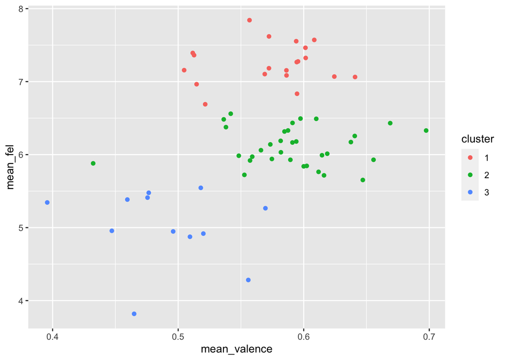

```r
km_cluster <- kmeans(cbind(valence_fel$mean_fel, valence_fel$mean_valence),
                     centers = 3)
valence_fel$cluster <- as.factor(km_cluster$cluster)
valence_fel %>% ggplot(aes(x = mean_valence, y = mean_fel, color = cluster)) +
  geom_point()
```

Se observa que podría separarse en 3 grupos a los países, en función de su índice de felicidad y el promedio de **valence** en las 50 canciones más populares que se escuchen en dicho país.

## Conclusiones

Se le puede dar una respuesta inicial a los objetivos del proyecto, se observa que hay una correlación muy pequeña de 0.3597504 entre el índice de felicidad y la positividad/negatividad en las canciones, que está dada por la característica *valence*.

Por otra parte, se observa una relación no lineal entre el índice de felicidad y el promedio de *valence* de las 50 canciones más escuchadas de cada país, y se puede hacer una separación por clusters de k-medias. Para este caso se vió que agrupar en 3 es adecuado.

Por último, para involucrar a las demás características numéricas restantes como *energy* o *acousticness*, lo que puede hacerse es aplicar algún algoritmo de clasificación tomando como base las clases creadas para el índice de felicidad, de bajo, medio, alto. Un algoritmo adecuado podría ser el de *k vecinos más cercanos* o bien algún algoritmo estadística de clasificación o de inferencia con lógica difusa. Un algoritmo como redes neuronales artificiales no sería muy adecuado por los pocos datos que se tienen.